# U1L2 - Principal Component Analysis

August 28, 2023

## Front Matter

```r
#Delete all objects from Environment - Use with caution
remove(list = ls())

#Load Libraries
library(tidyverse)
```

```r
library(GGally) #used for quickly creating all univariate and bivariate EDA plots
library(gridExtra) #used for orgainzing ggplot objects into a grid
library(factoextra) #Used for PCA plots
library(broom) #useful for creating plot of loadings when performing PCA
library(ISLR2) #used for USArrests dataset
library(ggrepel) #used to avoid overlapping text in some PCA plots

#Load Datasets
setwd("/home/maple/CodeProjects/Statistics/STAT508/notebooks")
nba_full <- read.csv("/home/maple/CodeProjects/Statistics/STAT508/sample_data/L02_NBA2223.csv")

#User-defined Functions
find_intersection <- function(x1, x2, slope){
  #This function finds the ordered pair (x1new,x2new) at which a 2D point (x1,x2)   would project onto a line passing through the origin with the given slope

  perpslope <- -1/slope
  x1new <- (x1 + slope * x2)/2
  x2new <- slope*x1new
  return(c(x1new,x2new))
}
```

## Example - Visualizing of NBA Data (Data Prep)

```r
#Subset the data to include TEAM name and 7 team statistics
nba <-
  nba_full %>%
  select(TEAM, W, L, PTS, FGM, AST, TOV, STL)
```

## Example - Visualizing of NBA Data (Data Prep) Part d.

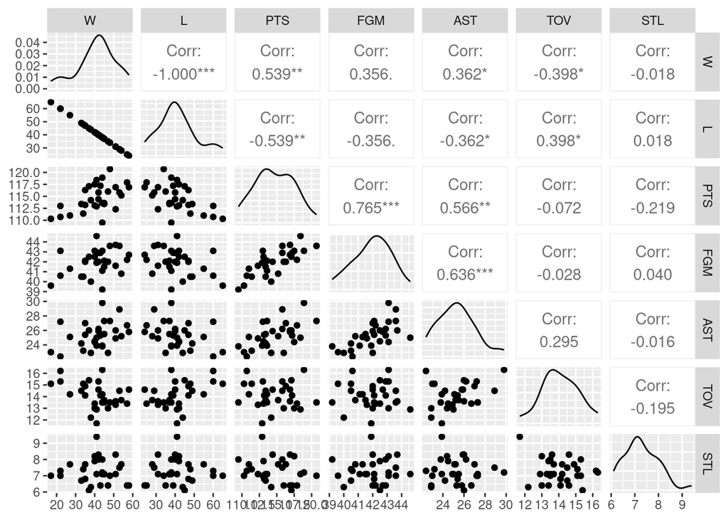

```r
#Create univariate and bivariate plots for 7 teams statistics mentioned in the problem (which are stored in columns 2 through 8)
ggpairs(data = nba, columns = 2:8, progress = FALSE)
```

## Example - Visualizing of NBA Data (Data Prep) Part e

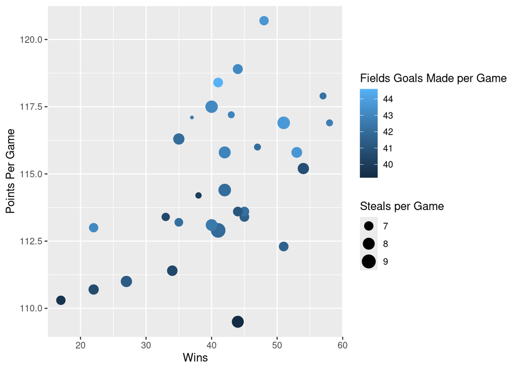

```r
#Explore the relationship between wins, points, field goals made, and steals
ggplot(data = nba, mapping = aes(x = W, y = PTS, color = FGM, size = STL)) +
  geom_point() +
  labs(x = "Wins",
       y = "Points Per Game",
       color = "Fields Goals Made per Game",
       size = "Steals per Game")
```

## Example - Genrarting a Toy Dataset

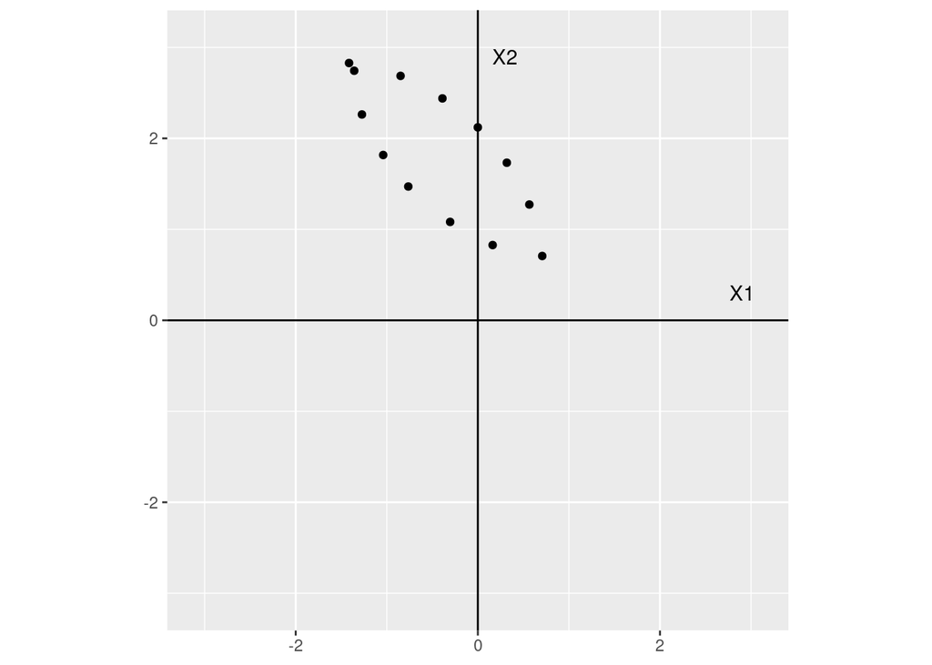

```r
#Create a "Toy1" dataset called Toy1 consisting of variables x1 and x2
x1 <- c(-3,-2.5,-2,-1.5,-1,-.5,0,-.47,-.98,-1.58,-2.02,-2.5,-2.9)
x2 <- c(1,1.3,1.45,1.5,1.45,1.3,1, .7,.55,.5,.55,.7,0.98)
Toy1 <- data.frame(x1 = x1, x2 = x2)

#Create a Rotation Matrix
R <- matrix(c(cos(pi/4), -sin(pi/4), sin(pi/4), cos(pi/4)),
            nrow=2,ncol=2,byrow=TRUE)

#Rotate Toy1 to create Toy2; The matrix multiplication uses the operator %*% and requires Toy1 to be a matrix instead of a data frame
Toy2 <- as.matrix(Toy1)%*%R

#Plot Toy2 - ggplot requires data to be a data frame
ggplot(data = as.data.frame(Toy2), mapping = aes(x = V1, y = V2)) +
  geom_point() +
  geom_hline(yintercept = 0, color = "black") +
  geom_vline(xintercept = 0, color = "black") +
  scale_x_continuous(limits=c(-3.1,3.1)) +
  scale_y_continuous(limits=c(-3.1,3.1)) +
  coord_fixed(ratio = 1) +
  annotate("text", x = 2.9, y = 0.3,
           label = "X1") +
  annotate("text", x = 0.3, y = 2.9,
           label = "X2") +
  theme(axis.title.x=element_blank(), #remove x axis title
        axis.title.y=element_blank())
```

## Example - Interpreting Covariance Matrix for Toy Dataset

```r
#Find the covariance matrix for Toy2
cov(Toy2)
```

```
##            [,1]       [,2]
## [1,]  0.5495949 -0.4056667
## [2,] -0.4056667  0.5401333
```

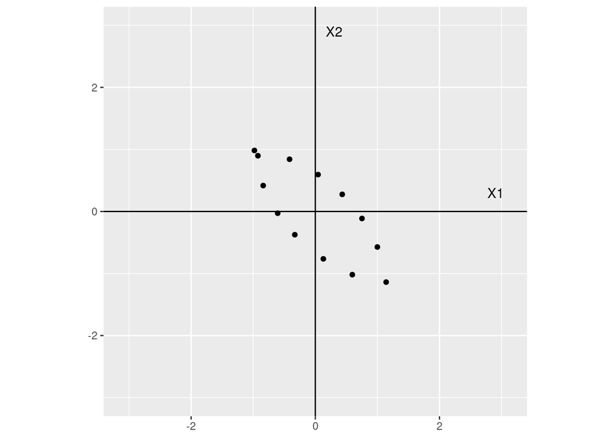

```r
#Create a centered version of Toy2
Toy2_c <- scale(Toy2, center = TRUE, scale = FALSE)

#Visualize Toy2 for the lecture notes
ggplot(data = as.data.frame(Toy2_c), mapping = aes(x = V1, y = V2)) +
  geom_point() +
  labs(x = "X1", y = "X2") +
  geom_hline(yintercept = 0, color = "black") +
  geom_vline(xintercept = 0, color = "black") +
  scale_x_continuous(limits=c(-3.1,3.1)) +
  scale_y_continuous(limits=c(-3,3)) +
  coord_fixed(ratio = 1) +
  annotate("text", x = 2.9, y = 0.3,
           label = "X1") +
  annotate("text", x = 0.3, y = 2.9,
           label = "X2") +
  theme(axis.title.x=element_blank(), #remove x axis title
        axis.title.y=element_blank())
```

## Example - Scalar Projection

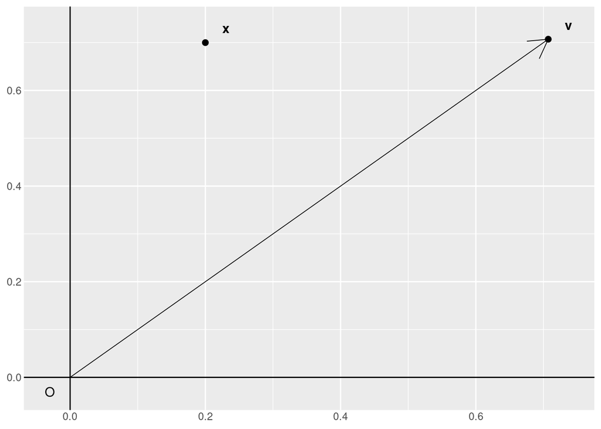

```r
#This code generates the plot given in the Scalar Projection example
ggplot(data = NULL) +
  geom_point(aes(x = 1/sqrt(2), y = 1/sqrt(2)), size = 2) +
  geom_point(aes(x = 0.2, y = 0.7), size = 2) +
  geom_hline(yintercept = 0) +
  geom_vline(xintercept = 0) +
  theme(axis.title.x=element_blank(), #remove x axis title
        axis.ticks.x=element_blank(), #remove x axis ticks
        axis.title.y=element_blank(),
        axis.ticks.y=element_blank()) +
  annotate("text", x =- 0.03, y = -0.03,
           label = "O") +
  annotate("text", x = (1/sqrt(2)) + 0.03, y = (1/sqrt(2)) + 0.03,
           label = "v", fontface = "bold") +
  annotate("text", x = 0.23, y = 0.73,
           label = "x", fontface = "bold") +
  annotate("segment", x = 0, xend = 1/sqrt(2), y = 0, yend = 1/sqrt(2),
           color = "black", linewidth = 0.3, arrow = arrow())
```

## Example - Using a Toy 2D Dataset to Illustrate the PCA Process – Step 1

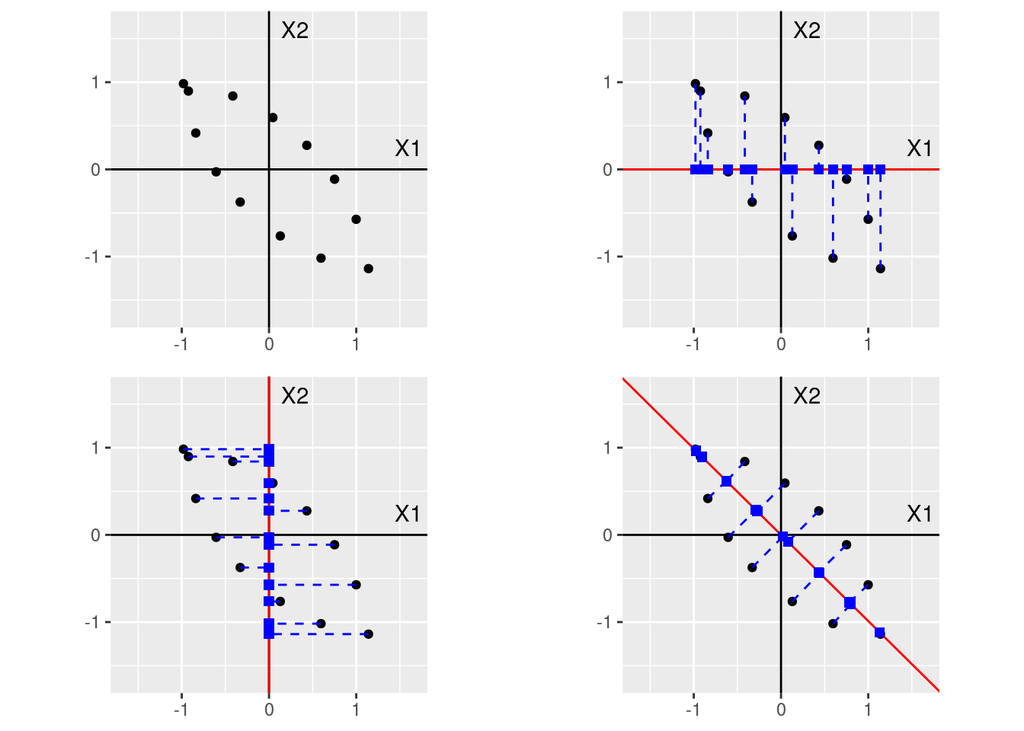

```r
#Center Toy2 so that columns are mean 0.
Toy2_c <- scale(Toy2, center = TRUE, scale = FALSE)

plot_Toy2_c <-
  ggplot(data = as.data.frame(Toy2_c), mapping = aes(x = V1, y = V2)) +
  geom_point() +
  geom_hline(yintercept = 0, color = "black") +
  geom_vline(xintercept = 0, color = "black") +
  scale_x_continuous(limits=c(-1.65,1.65)) +
  scale_y_continuous(limits=c(-1.65,1.65)) +
  coord_fixed(ratio = 1) +
  annotate("text", x = 1.6, y = 0.25,
           label = "X1") +
  annotate("text", x = 0.3, y = 1.6,
           label = "X2") +
  theme(axis.title.x=element_blank(), #remove x axis title
        axis.title.y=element_blank())

plotH <-
  plot_Toy2_c +
  geom_hline(yintercept = 0, color = "red") +
  geom_segment(x = Toy2_c[,1],
               y = Toy2_c[,2],
               xend = Toy2_c[,1],
               yend = 0,
               color = "blue",
               linetype = "dashed") +
  geom_point(aes(x = Toy2_c[,1], y = 0), color="blue",shape = 15, size = 2)

plotV <-
  plot_Toy2_c +
  geom_vline(xintercept = 0, color = "red") +
  geom_segment(x = Toy2_c[,1],
               y = Toy2_c[,2],
               xend = 0,
               yend = Toy2_c[,2],
               color = "blue",
               linetype = "dashed") +
  geom_point(aes(x = 0, y = Toy2_c[,2]), color="blue",shape = 15, size = 2)

#Perform PCA to find 1st PC
prcomp_res <- prcomp(Toy2_c)
temp_df <- t(apply(Toy2_c, 1, function(x) find_intersection(x[1], x[2], prcomp_res$rotation[2,1]/prcomp_res$rotation[1,1])))

plotD <-
  plot_Toy2_c +
  geom_abline(slope = prcomp_res$rotation[2,1]/prcomp_res$rotation[1,1],
              intercept = 0,
              color = "red") +
  geom_segment(x = Toy2_c[,1],
               y = Toy2_c[,2],
               xend = temp_df[,1],
               yend = temp_df[,2],
               color = "blue",
               linetype = "dashed") +
  geom_point(aes(x = temp_df[,1], y = temp_df[,2]), color="blue",shape = 15, size = 2)

#Arragnge the 4 plots into a two by two-grid
grid.arrange(plot_Toy2_c, plotH, plotV, plotD, ncol = 2)
```

## Example - Using a Toy 2D Dataset to Illustrate the PCA Process – Step 1 Rotation

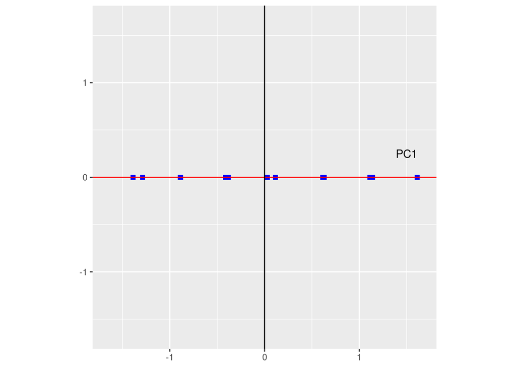

```r
#This code rotates the plot show that the 1st PC direction is the horizontal axis
plotD_rot <-
  ggplot(data = as.data.frame(prcomp_res$x),
       mapping = aes(x = PC1, y = PC2)) +
  geom_point(aes(x = PC1, y = 0), color="blue", shape = 15, size = 2) +
  geom_hline(yintercept = 0, color = "red") +
  geom_vline(xintercept = 0, color = "black") +
  scale_x_continuous(limits=c(-1.65,1.65)) +
  scale_y_continuous(limits=c(-1.65,1.65)) +
  coord_fixed(ratio = 1) +
  labs(y = "") +
  #annotate("text", x = -0.9, y = -1.2,
  #         label = paste("The variance of \n the projected points \nis ",
  #                       round(var(prcomp_res$x[,1]), digits = 2)), size = 2.2) +
  annotate("text", x = 1.5, y = 0.25,
           label = "PC1") +
  theme(axis.title.x=element_blank(), #remove x axis title
        axis.title.y=element_blank())

plotD_rot
```

## Example - Using a Toy 2D Dataset to Illustrate the PCA Process – Step 2

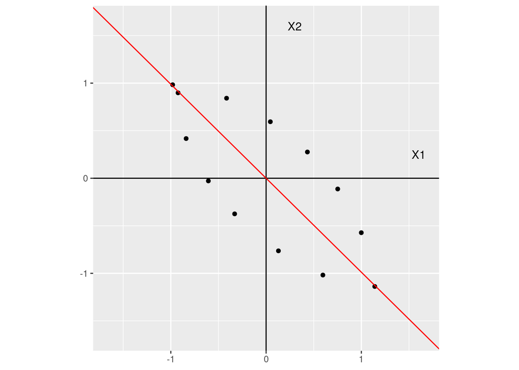

```r
#Create a plot showing the 1st PC
plot_Toy2_c +
  geom_abline(slope = prcomp_res$rotation[2,1]/prcomp_res$rotation[1,1],
              intercept = 0,
              color = "red")
```

## Example - Investigation of PCA Formulas

```r
#Create a "Toy1" dataset called Toy1 consisting of variables x1 and x2
x1 <- c(-3,-2.5,-2,-1.5,-1,-.5,0,-.47,-.98,-1.58,-2.02,-2.5,-2.9)
x2 <- c(1,1.3,1.45,1.5,1.45,1.3,1, .7,.55,.5,.55,.7,0.98)
Toy1 <- data.frame(x1 = x1, x2 = x2)

#Create a Rotation Matrix
R <- matrix(c(cos(pi/4), -sin(pi/4), sin(pi/4), cos(pi/4)),
            nrow=2,ncol=2,byrow=TRUE)

#Rotate Toy1 to create Toy2; The matrix multiplication uses the operator %*% and requires Toy1 to be a matrix instead of a data frame
Toy2 <- as.matrix(Toy1)%*%R
```

#### Part a - Center the dataset

```r
Toy2c <- scale(x = Toy2, center = TRUE, scale = FALSE)
```

Calculate the sample covariance matrix:

$$\hat{\sum} = \frac{1}{n - 1}X^TX$$

#### Part b - Calculate the sample covariance matrix

```r
#Calculate sample covariance using formula
C <- (1 /(nrow(Toy2c) - 1)) * t(Toy2c) %*%  Toy2c
C
```

```
##            [,1]       [,2]
## [1,]  0.5495949 -0.4056667
## [2,] -0.4056667  0.5401333
```

```r
#Use cov() function to verify our calculation
cov(Toy2)
```

```
##            [,1]       [,2]
## [1,]  0.5495949 -0.4056667
## [2,] -0.4056667  0.5401333
```

#### Part c - Find the eigenvalues and eigenvectors of the covariance matrix

```r
#Find the eigenvalues and eigenvectors
eigenInfo <- eigen(x = C)
eigenInfo
```

```
## eigen() decomposition
## $values
## [1] 0.9505584 0.1391699
##
## $vectors
##            [,1]       [,2]
## [1,] -0.7112176 -0.7029719
## [2,]  0.7029719 -0.7112176
```

Note that the eigenvectors are the columns of `eigenInfo$vectors`.

Eigenvectors are unique up to a sign flip (i.e., multiply each element in the vector by -1).

#### Part d - Plot the centered data and add the eigenvectors

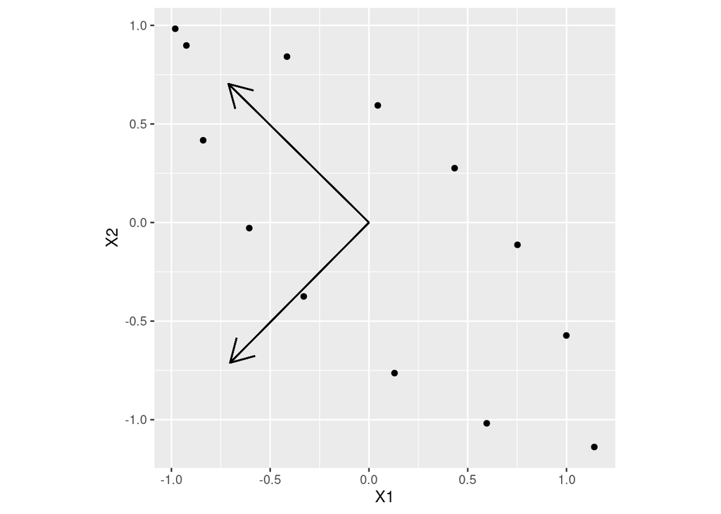

```r
ggplot(data = as.data.frame(Toy2c), aes(x = V1, y = V2)) +
  geom_point() +
  labs(x = "X1",
       y = "X2") +
  geom_segment(x = 0, y = 0,
               xend = eigenInfo$vectors[1,1],
              yend = eigenInfo$vectors[2,1],
              arrow = arrow())+
  geom_segment(x = 0, y = 0,
               xend = eigenInfo$vectors[1,2],
              yend = eigenInfo$vectors[2,2],
              arrow = arrow()) +
  coord_fixed()
```

#### Part e - Project the original data onto the PC’s (i.e., find the scores) and plot

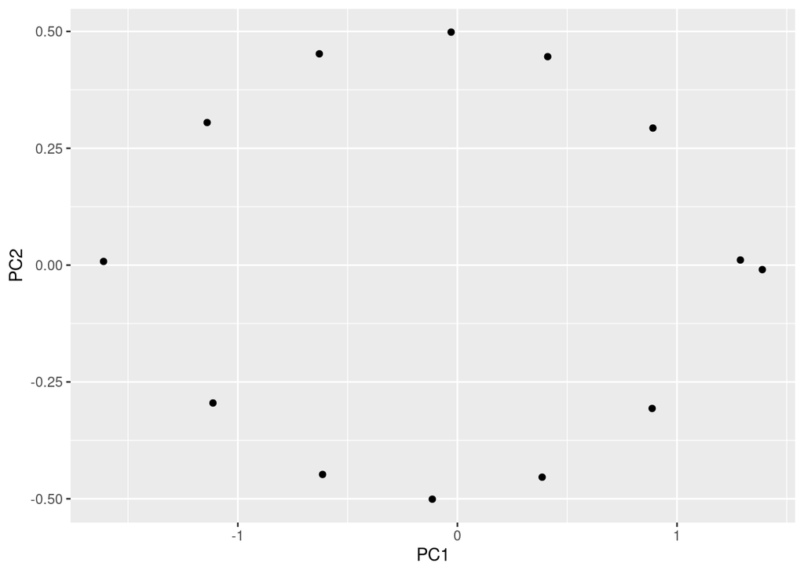

```r
#Calculate the coordinates and project the data
Z <- Toy2c %*% eigenInfo$vectors

#Visualize the result
ggplot(data = as.data.frame(Z),
       mapping = aes(x = V1, y = V2)) +
  geom_point() +
  labs(x = "PC1",
       y = "PC2")
```

#### Part f - Find the covariance matrix for Z

```r
#Find the covariance of Z
cov(Z)
```

```
##               [,1]          [,2]
## [1,]  9.505584e-01 -1.460962e-17
## [2,] -1.460962e-17  1.391699e-01
```

```r
# Round the covariance matrix
round(cov(Z), digits = 7)
```

```
##           [,1]      [,2]
## [1,] 0.9505584 0.0000000
## [2,] 0.0000000 0.1391699
```

It is not surprising that the covariances are 0 (within machine precision) since the PC’s are orthogonal (uncorrelated).

The elements along the main diagonal of any covariance matrix are variances. In this context the main diagonal elements are the variance of the projected points in each direction (the directions are the PC’s).

#### Part g - Verify that eigenvalues represent variance

```r
eigenInfo$values
```

```
## [1] 0.9505584 0.1391699
```

```r
# eigen values are the variances of the projected point.
```

#### Part h - Find the proportion of variance explained by each PC

To findt he proportion of variance explained, divide each eigan value by the sum of the eigan values

```r
PVE <- eigenInfo$values/sum(eigenInfo$values)
PVE
```

```
## [1] 0.8722894 0.1277106
```

The first PC explains 87.2% of the total variance, while the second PC explains 12.8%

#### Part i - Use the prcomp() function to find the eigenvalues, eigenvectors, and projected data.

```r
#Use prcomp to perform PCA
prcomp_res <- prcomp(x = Toy2, center = TRUE, scale. = FALSE)
#Eigenvalues
prcomp_res$sdev^2
#Eigenvectors
prcomp_res$rotation
#Projected Data gives us Z
prcomp_res$x

#Plot projected Data
ggplot(data = as.data.frame(prcomp_res$x),
       mapping = aes(x = PC1, y = PC2)) +
  geom_point() +
  labs(x = "PC1",
       y = "PC2")
```

[output not shown]

#### Part j - Compare eigenvalues, eigenvectors from the two methods

```r
#Compare eigenvalues
eigenInfo$values
prcomp_res$sdev^2

#Compare eigenvectors
eigenInfo$vectors
prcomp_res$rotation
```

[output not shown]

```r
#Create plot showing eigenvectors from prcomp and from eigen
ggplot(data = as.data.frame(Toy2c), mapping = aes(x = V1, y = V2)) +
  geom_point() +
  geom_segment(x = 0, y = 0,
               xend = eigenInfo$vectors[1,1],
               yend = eigenInfo$vectors[2,1],
               arrow = arrow(length = unit(0.5, "cm"))) +
  geom_segment(x = 0, y = 0,
               xend = eigenInfo$vectors[1,2],
               yend = eigenInfo$vectors[2,2],
               arrow = arrow(length = unit(0.5, "cm"))) +
  geom_segment(x = 0, y = 0,
               xend = prcomp_res$rotation[1,1],
               yend = prcomp_res$rotation[2,1],
               arrow = arrow(),
               color = "red", linetype = "dashed") +
  geom_segment(x = 0, y = 0,
               xend = prcomp_res$rotation[1,2],
               yend = prcomp_res$rotation[2,2],
               arrow = arrow(),
               color = "red", linetype = "dashed") +
  coord_fixed()
```

[output not shown]

## Example - PCA on US Arrests Data

#### Preliminaries

```r
#Create a copy of the dataset in the environment
data(USArrests)
```

#### Part a - Initial EDA

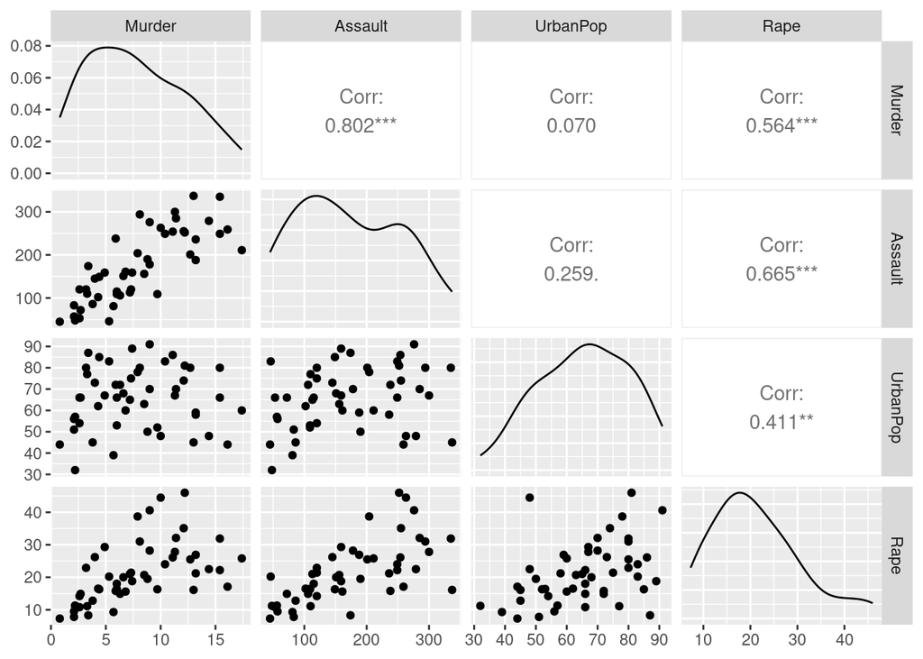

```r
#Generate all univariate and bivariate plots
ggpairs(data = USArrests, progress = FALSE)
```

```r
#Calculate mean and standard deviation for the numeric variables
USArrests %>%
  summarize(MeanM = mean(Murder),
            MeanA = mean(Assault),
            MeanR = mean(Rape),
            MeanUP = mean(UrbanPop),
            sdM = sd(Murder),
            sdA = sd(Assault),
            sdR = sd(Rape),
            sdUP = sd(UrbanPop))
```

```
##   MeanM  MeanA  MeanR MeanUP     sdM      sdA      sdR     sdUP
## 1 7.788 170.76 21.232  65.54 4.35551 83.33766 9.366385 14.47476
```

#### Part b - Perform PCA using the standardized data

```r
USArrests_pca <- prcomp(x = USArrests, center = TRUE, scale. = TRUE)

#Eigenvalues
USArrests_pca$sdev^2
```

```
## [1] 2.4802416 0.9897652 0.3565632 0.1734301
```

```r
#Eigenvectors
USArrests_pca$rotation
```

```
##                 PC1        PC2        PC3         PC4
## Murder   -0.5358995 -0.4181809  0.3412327  0.64922780
## Assault  -0.5831836 -0.1879856  0.2681484 -0.74340748
## UrbanPop -0.2781909  0.8728062  0.3780158  0.13387773
## Rape     -0.5434321  0.1673186 -0.8177779  0.08902432
```

```r
#First 6 rows of Projected Data (also called the scores)
head(USArrests_pca$x)
```

```
##                   PC1        PC2         PC3          PC4
## Alabama    -0.9756604 -1.1220012  0.43980366  0.154696581
## Alaska     -1.9305379 -1.0624269 -2.01950027 -0.434175454
## Arizona    -1.7454429  0.7384595 -0.05423025 -0.826264240
## Arkansas    0.1399989 -1.1085423 -0.11342217 -0.180973554
## California -2.4986128  1.5274267 -0.59254100 -0.338559240
## Colorado   -1.4993407  0.9776297 -1.08400162  0.001450164
```

#### Part c - Proportion of the total variance explained

```r
#Calculate the proportion of variance explained for each PC
PVE <- USArrests_pca$sdev^2/sum(USArrests_pca$sdev^2)
PVE
```

```
## [1] 0.62006039 0.24744129 0.08914080 0.04335752
```

#### Part d - Create a scree plot

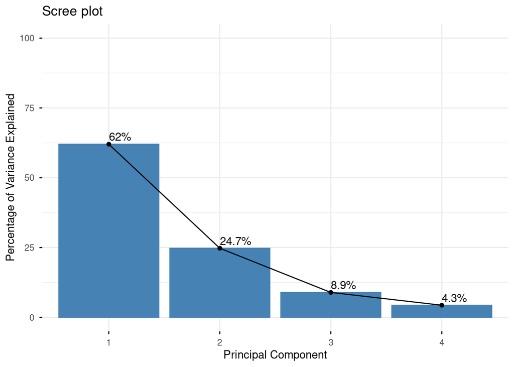

```r
#Create scree plot of PVE
fviz_screeplot(X = USArrests_pca,
               geom = c("bar", "line"),
               choice = "variance",
               ncp = 4, #Controls number of PC's displayed (change for other datasets)
               addlabels = TRUE #Adds percentages near points on plot
               ) +
  labs(x = "Principal Component",
       y = "Percentage of Variance Explained") +
  scale_y_continuous(limits = c(0,100))
```

#### Part e - Create a plot of the cumulative proportion of variance explained

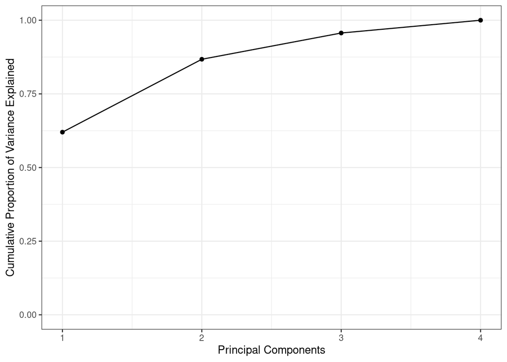

```r
#Create a data frame for plotting
cumPVE_df <- data.frame(PC = 1:ncol(USArrests), CumVarExp = cumsum(PVE))

#Create Cumulative Proportion of Variance Explained Plot
ggplot(data = cumPVE_df, mapping = aes(x = PC, y = CumVarExp)) +
  geom_point() +
  geom_line() +
  scale_y_continuous(limits = c(0,1)) +
  labs(x = "Principal Components",
       y = "Cumulative Proportion of Variance Explained") +
  theme_bw()
```

#### Part g - Visualization of points projected onto the first two PC’s

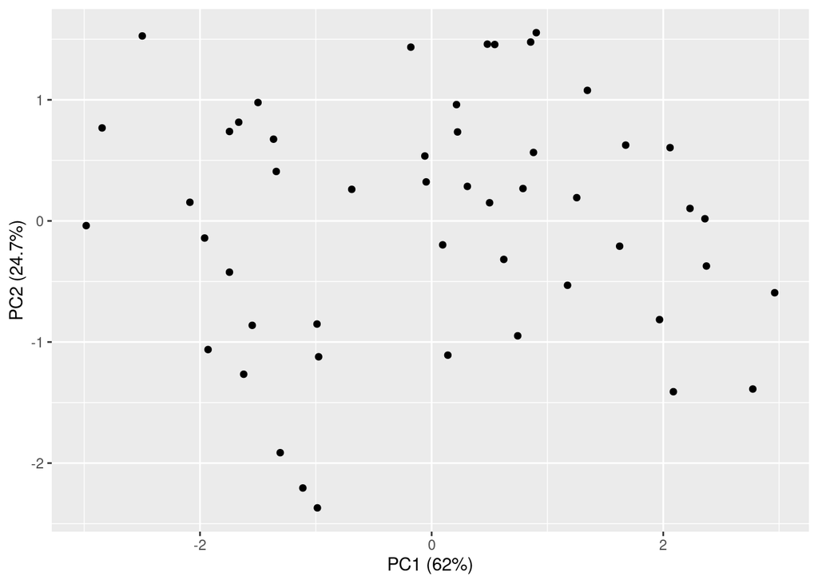

```r
ggplot(data = as.data.frame(USArrests_pca$x),
       mapping = aes(x = PC1, y = PC2)) +
  geom_point() +
  labs(x = paste("PC1 (", round(100*PVE[1], digits = 1), "%)", sep = ""),
       y = paste("PC2 (", round(100*PVE[2], digits = 1), "%)", sep = ""))
```

```r
  #geom_label_repel(aes(label = State),
                  #box.padding   = 0.35,
                  #point.padding = 0.5,
                  #segment.color = 'grey50')
```

#### Part i - Visualize the loadings

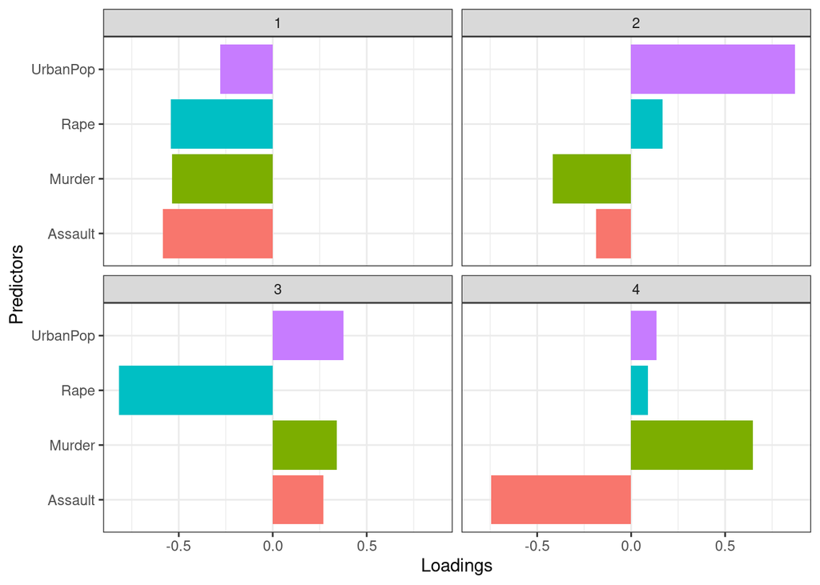

```r
#Create plot of loadings
tidy(USArrests_pca, matrix = "loadings") %>% #tidy is from the broom package
  ggplot(aes(x = value, y = column)) +
  facet_wrap(~ PC) +
  geom_col(aes(fill=column),show.legend = F)+
  labs(x= "Loadings",y="Predictors")+
  theme_bw()
```

#### Part j - Label the points using the state names

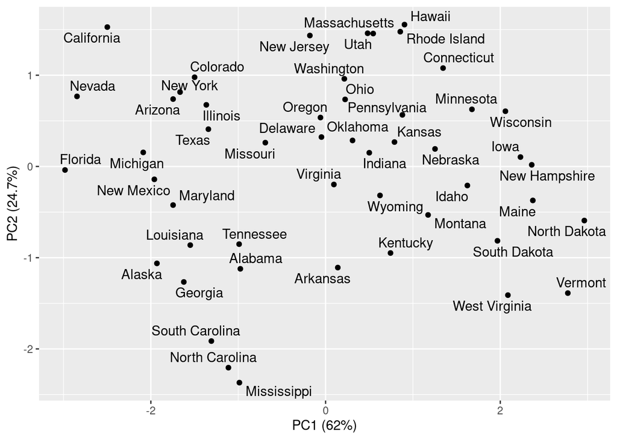

```r
#Create the 2D visualization but add the row names as labels on the points
ggplot(data = as.data.frame(USArrests_pca$x),
       mapping = aes(x = PC1, y = PC2)) +
  geom_point() +
  labs(x = paste("PC1 (", round(100*PVE[1], digits = 1), "%)", sep = ""),
       y = paste("PC2 (", round(100*PVE[2], digits = 1), "%)", sep = "")) +
  geom_text_repel(mapping = aes(label = row.names(USArrests),
                  segment.color = 'grey50'))
```

#### Part k - Create the biplot

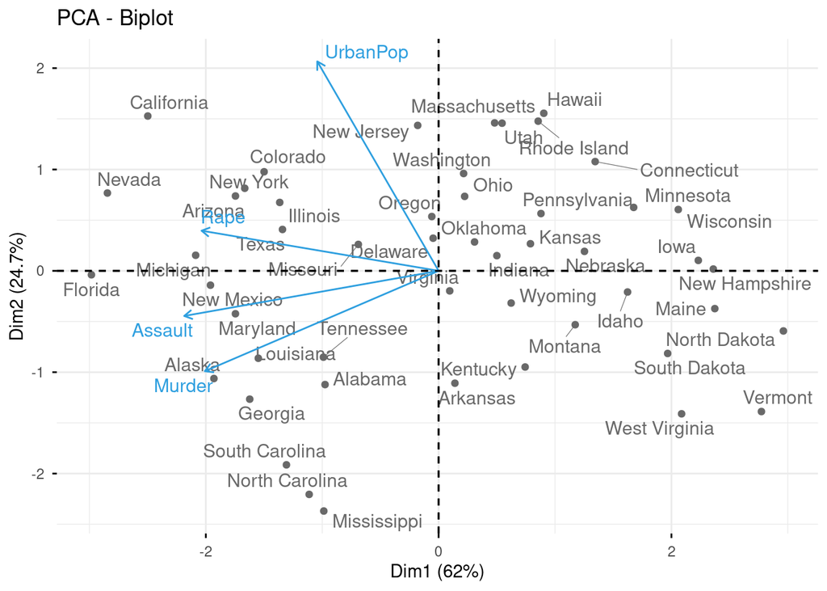

```r
fviz_pca_biplot(USArrests_pca, repel = TRUE,
                col.var = "#2E9FDF", # Variables color
                col.ind = "#696969"  # Individuals color
                )
```

## Example - PCA on Centered (but not Scaled) US Arrests Data

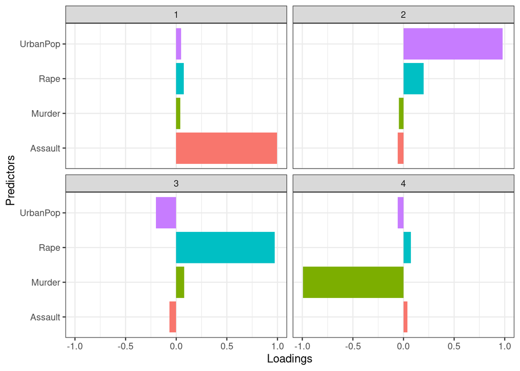

```r
USArrests_pca_unscaled <- prcomp(x = USArrests, center = TRUE, scale. = FALSE)

#Create plot of loadings
tidy(USArrests_pca_unscaled, matrix = "loadings") %>% #tidy is from the broom package
  ggplot(aes(x = value, y = column)) +
  facet_wrap(~ PC) +
  geom_col(aes(fill=column),show.legend = F)+
  labs(x= "Loadings",y="Predictors")+
  theme_bw()
```